# RPU 2013 Analyse

#### Exhaustivité des items

Il faut tranformer les valeurs NULL en NA pour pouvoir les comptabiliser. Les valeurs NULL apparaissent pour les factors: DP, MOTIF, TRANSPORT, ORIENTATION,GRAVITE, SORTIE. Il faut les transformer en character pour leur attriber la valeur NA au lieu de NULL:

```r
a <- as.character(d1$DP)
a[a == "NULL"] <- NA
sum(is.na(a))
```

```
## [1] 114865
```

```r
mean(is.na(a))
```

```
## [1] 0.3375
```

sum(is.na(a)) retourne le nombre de lignes concernées et *mean(is.na(a))* donne directement le pourcentage de valeurs nulles (R in action pp 356)

```r
d1$DP <- a

a <- as.character(d1$MOTIF)
a[a == "NULL"] <- NA
d1$MOTIF <- a

a <- as.character(d1$TRANSPORT)
a[a == "NULL"] <- NA
d1$TRANSPORT <- a

a <- as.character(d1$ORIENTATION)
a[a == "NULL"] <- NA
d1$ORIENTATION <- a

a <- as.character(d1$GRAVITE)
a[a == "NULL"] <- NA
d1$GRAVITE <- a

a <- as.character(d1$SORTIE)
a[a == "NULL"] <- NA
d1$SORTIE <- a

a <- as.character(d1$ENTREE)
a[a == "NULL"] <- NA
d1$ENTREE <- a
```

Les 2 lignes qui suivent comptent les NA

```r
a <- is.na(d1)
b <- apply(a, 2, mean)
a <- cbind(sort(round(b * 100, 2)))
colnames(a) <- "%"
a
```

```
##                   %
## id             0.00
## CODE_POSTAL    0.00
## COMMUNE        0.00
## ENTREE         0.00
## EXTRACT        0.00
## FINESS         0.00
## NAISSANCE      0.00
## SEXE           0.00
## AGE            0.00
## SORTIE         8.91
## MODE_ENTREE    9.45
## MODE_SORTIE   14.02
## GRAVITE       14.37
## TRANSPORT     23.30
## TRANSPORT_PEC 25.50
## DP            33.75
## PROVENANCE    35.05
## MOTIF         35.75
## DESTINATION   78.74
## ORIENTATION   79.95
```

```r
a <- d1$MODE_SORTIE[MODE_SORTIE == "Mutation" | MODE_SORTIE == "Transfert"]
a <- na.omit(a)
a <- as.factor(as.character(a))
summary(a)
```

```
##  Mutation Transfert
##     67665      4877
```

```r
round(prop.table(table(a)) * 100, 2)
```

```
## a
##  Mutation Transfert
##     93.28      6.72
```

```r
a <- d1[MODE_SORTIE == "Mutation" | MODE_SORTIE == "Transfert", ]
a <- na.omit(a)
summary(a$DESTINATION)
```

```
##    NA   MCO   SSR   SLD   PSY   HAD   HMS
##     0 25382     4     5   427     0     0
```

```r
summary(as.factor(a$ORIENTATION))
```

```
##  CHIR   HDT    HO   MED  OBST   PSA   REA    SC    SI  UHCD
##  5423    65    16 12185    46     1   736  1033   950  5363
```

```r
round(prop.table(table(as.factor(a$ORIENTATION))) * 100, 2)
```

```
##
##  CHIR   HDT    HO   MED  OBST   PSA   REA    SC    SI  UHCD
## 21.00  0.25  0.06 47.20  0.18  0.00  2.85  4.00  3.68 20.77
```

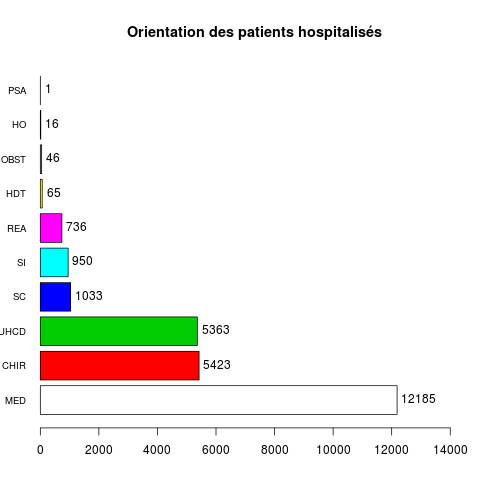

```
## as.factor(a$ORIENTATION) :
##         Frequency Percent Cum. percent
## MED         12185    47.2         47.2
## CHIR         5423    21.0         68.2
## UHCD         5363    20.8         89.0
## SC           1033     4.0         93.0
## SI            950     3.7         96.7
## REA           736     2.9         99.5
## HDT            65     0.3         99.8
## OBST           46     0.2         99.9
## HO             16     0.1        100.0
## PSA             1     0.0        100.0
##   Total     25818   100.0        100.0
```

```r
tab1(as.factor(a$ORIENTATION), sort.group = "decreasing", horiz = TRUE, cex.names = 0.8,
    xlab = "", main = "Orientation des patients hospitalisés")
```

```r
a <- d1[d1$MODE_SORTIE == "Domicile", ]
summary(as.factor(a$ORIENTATION))
```

```
##   CHIR  FUGUE    HDT     HO    MED   OBST    PSA    REA    REO     SC
##    134    255     16      2     73      2   3015     10   1394      6
##   SCAM     SI   UHCD   NA's
##    512     36    283 262056
```

```r
t <- table(as.factor(a$ORIENTATION))
round(prop.table(t) * 100, 2)
```

```
##
##  CHIR FUGUE   HDT    HO   MED  OBST   PSA   REA   REO    SC  SCAM    SI
##  2.34  4.44  0.28  0.03  1.27  0.03 52.54  0.17 24.29  0.10  8.92  0.63
##  UHCD
##  4.93
```

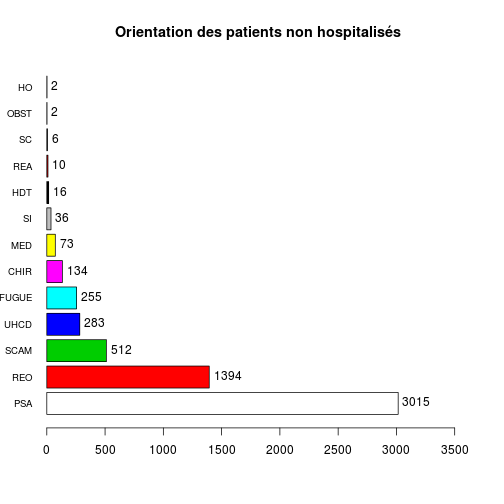

```
## as.factor(a$ORIENTATION) :
##         Frequency   %(NA+)   %(NA-)
## NA's       262056     97.9      0.0
## PSA          3015      1.1     52.5
## REO          1394      0.5     24.3
## SCAM          512      0.2      8.9
## UHCD          283      0.1      4.9
## FUGUE         255      0.1      4.4
## CHIR          134      0.1      2.3
## MED            73      0.0      1.3
## SI             36      0.0      0.6
## HDT            16      0.0      0.3
## REA            10      0.0      0.2
## SC              6      0.0      0.1
## HO              2      0.0      0.0
## OBST            2      0.0      0.0
##   Total    267794    100.0    100.0
```

```r
tab1(as.factor(a$ORIENTATION), sort.group = "decreasing", horiz = TRUE, cex.names = 0.8,
    xlab = "", main = "Orientation des patients non hospitalisés", missing = F)
```

La table ci-dessus liste le devenir des patients non hospitalisés. On note des incohérences: REA, HDT, SI, Med, CHIR, UHCD. La ligne *Missing* correspond aux patients rentrés sur avis médical.